# Plate reader growth curves of GAT201 mutants in RPMI and YPD

Liz Hughes & Edward Wallace

02/05/2023

# Summary

Plate reader growth curves of GAT201 mutants

Design:

- Wild-type H99/GAT201, and gat201∆ strains: gat201∆m (Madhani) and gat201∆b (Bahn) in RPMI and YPD at 37 degrees in TECAN plate reader.
- 7 Biological replicates, 3 Technical replicates each. (NB only 2 Techreps for Biorep 7)
- Grow 5ml culture from colony (1 colony = 1 Biorep) in YPD, 30C, 250 rpm ON.
- Seed at OD 600nm = 0.2 , 200 ul per well.
- Run for 3 days/ 72h

# Set up data frame of nice strain names, colours, styles.

```r
strain_df <- tibble( Strain = c("H99", "Gat201(B)", "Gat201(M)", "C26", "C30" ),
                     Strain_nice = c("GAT201", "gat201∆b","gat201∆m", "GAT201-C1", "GAT201-C2"),
                     colour = c("grey20", "magenta3", "darkred", "blue3", "cyan4"))
```

# RPMI media analysis

## Read in transposed data as csv file RPMI

```r
raw_od_RPMI <-
  here::here("data", "20200728_EH_PR2_RPMI_WT_Gat201.xlsx") %>%
  read_platereader_xlsx(start_row = 52)
```

## Read in the Plate map data from csv file RPMI

Also combine with nice strain names for display.

```r
platemap_RPMI <-
  here::here("data", "20200728_EH_PR2_RPMI_Setup.csv") %>%
  read_platemap_csv(strain_df = strain_df)

head(platemap_RPMI, n=10)
```

```
## # A tibble: 10 × 7
##    Well  Strain Biorep Techrep Medium Strain_nice colour
##    <chr> <chr>   <dbl>   <dbl> <chr>  <chr>       <chr>
##  1 A1    <NA>       NA      NA RPMI   <NA>        <NA>
##  2 A2    <NA>       NA      NA RPMI   <NA>        <NA>
##  3 A3    <NA>       NA      NA RPMI   <NA>        <NA>
##  4 A4    <NA>       NA      NA RPMI   <NA>        <NA>
##  5 A5    <NA>       NA      NA RPMI   <NA>        <NA>
##  6 A6    <NA>       NA      NA RPMI   <NA>        <NA>
##  7 A7    <NA>       NA      NA RPMI   <NA>        <NA>
##  8 A8    <NA>       NA      NA RPMI   <NA>        <NA>
##  9 A9    <NA>       NA      NA RPMI   <NA>        <NA>
## 10 A10   <NA>       NA      NA RPMI   <NA>        <NA>
```

## Reshape data and combine with the plate map, pairing them by Well RPMI

```r
annotated_od_RPMI <-
  reshape_annotate_raw_od(raw_od = raw_od_RPMI, platemap = platemap_RPMI)
```

## Plot blank ODs RPMI

To find how stable the ODs of the blank wells are.

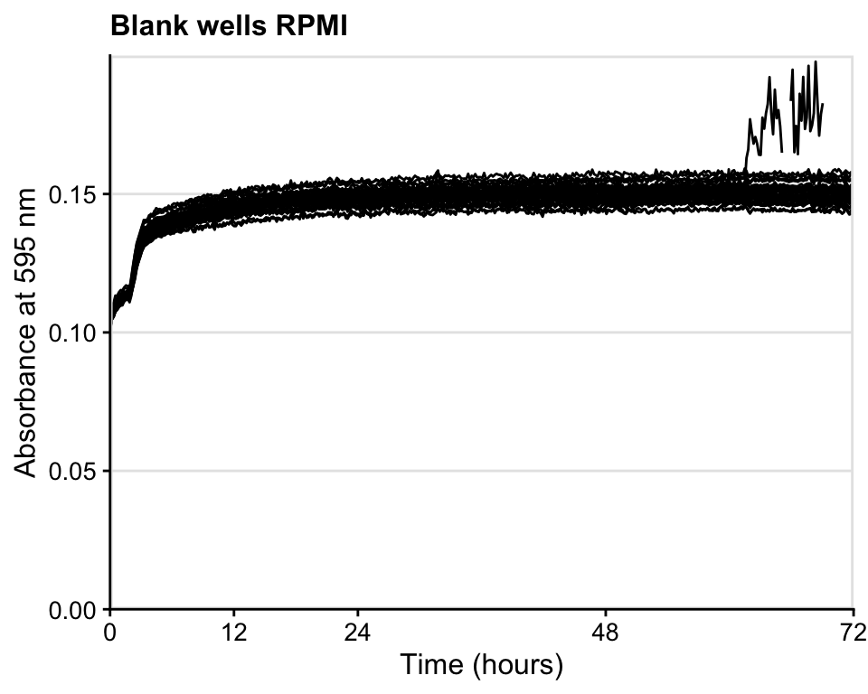

```r
ggplot(data=filter(annotated_od_RPMI, is.na(Strain)),
       aes(x=Time, y=OD595,  group = Well)) +
  geom_line() +
  scale_time_hrs() +
  scale_y_continuous(limits = c(0, 0.2),
                     expand = c(0, 0),
                     breaks = c(0, 0.05, 0.1, 0.15)) +
  labs(title = "Blank wells RPMI", x="Time (hours)", y="Absorbance at 595 nm")
```

This shows that the OD increases over time, presumably pH change of the phenol red indicator. We correct for this.

## Calculate median OD for blank wells RPMI

Remove well H2 that had a strange reading above.

```r
# filter out columns 1 and 12 as well?
blank_od_summary_RPMI <-
  summarise_od_fixed(annotated_od_RPMI, od.name = "OD595",
                     is.na(Strain),
                     Well != "H2")

print(blank_od_summary_RPMI)
```

```
## # A tibble: 1 × 4
##   OD_median OD_mean OD_max OD_min
##       <dbl>   <dbl>  <dbl>  <dbl>
## 1     0.149   0.147  0.159  0.100
```

```r
blank_od_time_RPMI <-
  summarise_od_bytime(annotated_od_RPMI, od.name = "OD595",
                     is.na(Strain),
                     Well != "H2")

print(blank_od_time_RPMI)
```

[output not shown]

## Subtract blank OD to make corrected OD RPMI

```r
normalised_od_RPMI <-
  normalise_od_2ways(annotated_od_RPMI, is.na(Strain))
```

## Plot OD corrected by time-based median summary RPMI

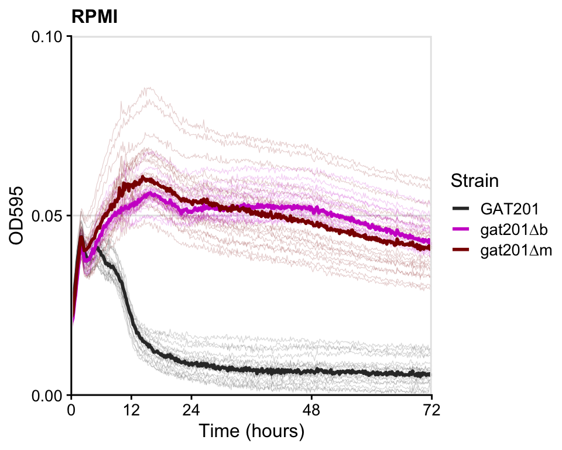

```r
RPMI_plot <-
  ggplot_growthcurve_summary(data_od = normalised_od_RPMI %>%
                               filter(!is.na(Strain)),
                             value_od = "OD_corrected_time",
                             limits_time = c(0,72),
                             limits_od = c(0, 0.1),
                             breaks_od = c(0, 0.05, 0.1)) +
  scale_color_strain(strain_df)  +
  labs(title = "RPMI")

RPMI_plot
```

```r
here::here("results",
           "20200728_EH_PR2_RPMI_WT_Gat201_summaryplot.png") %>%
  ggsave(plot = RPMI_plot,
         width = 5.1, height = 3.75)
```

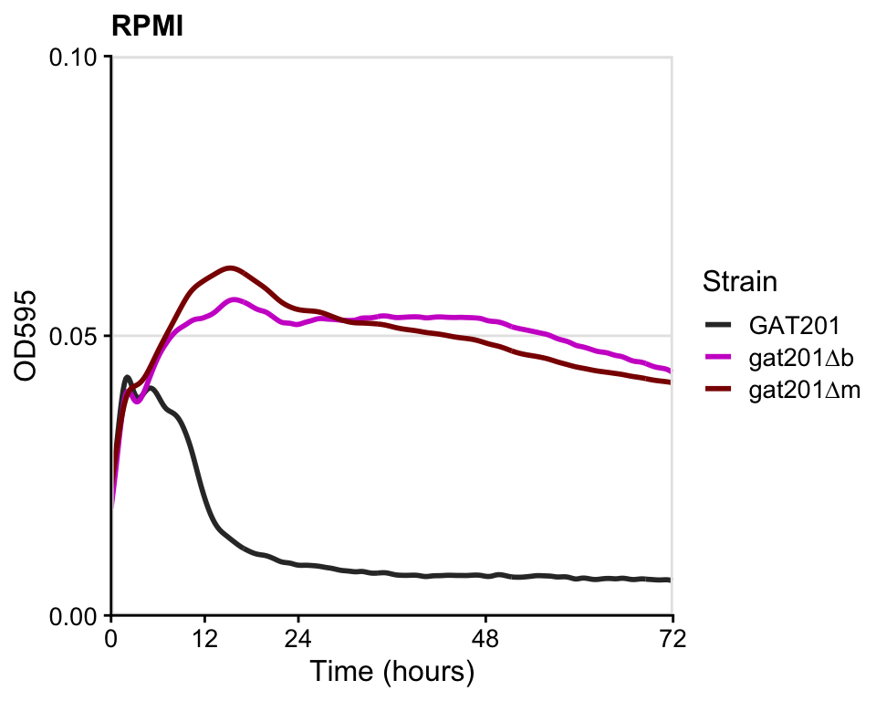

```r
RPMI_spline_plot <-
  ggplot_growthcurve_spline(data_od = normalised_od_RPMI %>%
                              filter(!is.na(Strain)),
                            value_od = "OD_corrected_time",
                            limits_time = c(0,72),
                            limits_od = c(0, 0.1),
                            breaks_od = c(0, 0.05, 0.1)) +
  scale_color_strain(strain_df)  +
  labs(title = "RPMI")

RPMI_spline_plot
```

# YPD media analysis

## Read in transposed data as csv file YPD

```r
raw_od_YPD <-
  here::here("data", "20200807_EH_PR4_YPD_WT_Gat201.xlsx") %>%
  read_platereader_xlsx(start_row = 52)
```

## Read in the Plate map data from csv file YPD

Also combine with nice strain names for display.

```r
platemap_YPD <-
  here::here("data", "20200807_EH_PR4_YPD_Setup.csv") %>%
  read_platemap_csv(strain_df = strain_df)

head(platemap_YPD, n=10)
```

```
## # A tibble: 10 × 7
##    Well  Strain Biorep Techrep Medium Strain_nice colour
##    <chr> <chr>   <dbl>   <dbl> <chr>  <chr>       <chr>
##  1 A1    <NA>       NA      NA YPD    <NA>        <NA>
##  2 A2    <NA>       NA      NA YPD    <NA>        <NA>
##  3 A3    <NA>       NA      NA YPD    <NA>        <NA>
##  4 A4    <NA>       NA      NA YPD    <NA>        <NA>
##  5 A5    <NA>       NA      NA YPD    <NA>        <NA>
##  6 A6    <NA>       NA      NA YPD    <NA>        <NA>
##  7 A7    <NA>       NA      NA YPD    <NA>        <NA>
##  8 A8    <NA>       NA      NA YPD    <NA>        <NA>
##  9 A9    <NA>       NA      NA YPD    <NA>        <NA>
## 10 A10   <NA>       NA      NA YPD    <NA>        <NA>
```

## Reshape data and combine with the plate map, pairing them by Well YPD

```r
annotated_od_YPD <-
  reshape_annotate_raw_od(raw_od = raw_od_YPD, platemap = platemap_YPD)
```

## Plot blank ODs YPD

To find how stable the ODs of the blank wells are.

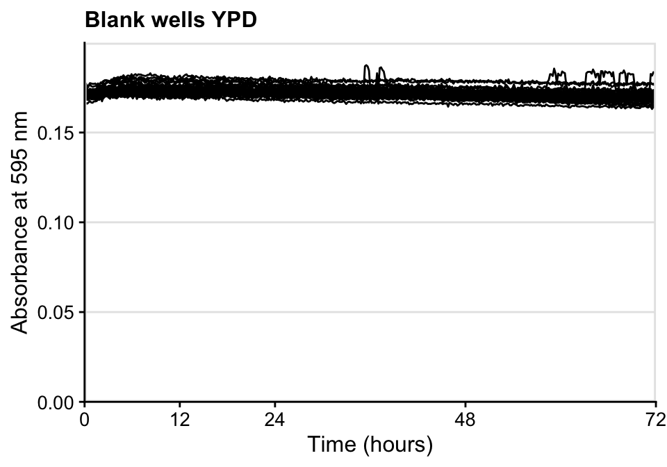

```r
ggplot(data=filter(annotated_od_YPD, is.na(Strain)),
           aes(x=Time, y=OD595,  group = Well)) +
  geom_line() +
  scale_time_hrs() +
  scale_y_continuous(limits = c(0, 0.2),
                     expand = c(0, 0),
                     breaks = c(0, 0.05, 0.1, 0.15)) +
  labs(title = "Blank wells YPD", x="Time (hours)", y="Absorbance at 595 nm")
```

## Calculate median OD for blank wells for YPD

```r
# filter out columns 1 and 12 as well?
blank_od_summary_YPD <-
  summarise_od_fixed(annotated_od_YPD, od.name = "OD595",
                     is.na(Strain))

print(blank_od_summary_YPD)
```

```
## # A tibble: 1 × 4
##   OD_median OD_mean OD_max OD_min
##       <dbl>   <dbl>  <dbl>  <dbl>
## 1     0.172   0.172  0.188  0.162
```

```r
blank_od_time_YPD <-
  summarise_od_bytime(annotated_od_YPD, od.name = "OD595",
                     is.na(Strain))

print(blank_od_time_YPD)
```

[output not shown]

## Subtract blank OD to make corrected OD YPD

```r
normalised_od_YPD <-
  normalise_od_2ways(annotated_od_YPD, is.na(Strain))
```

## Plot OD corrected by time-based median summary YPD

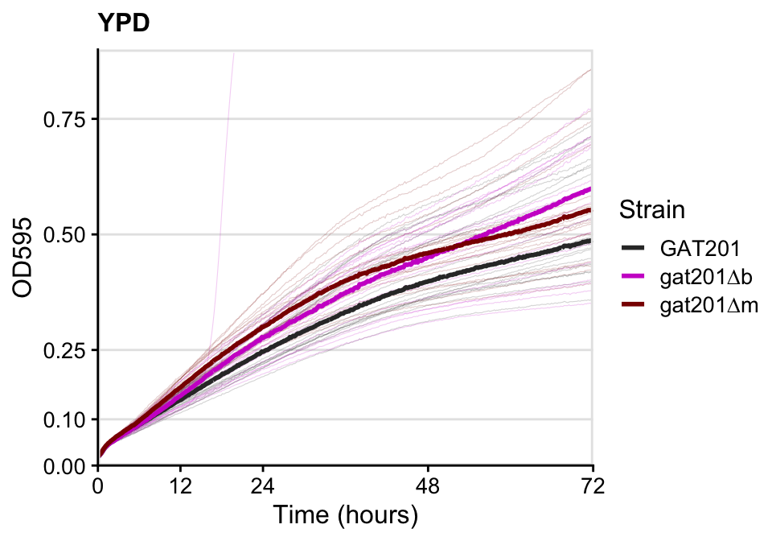

```r
YPD_plot  <-
  ggplot_growthcurve_summary(data_od = normalised_od_YPD %>%
                               filter(!is.na(Strain)),
                             value_od = "OD_corrected_time",
                             limits_time = c(0,72),
                             limits_od = c(0, 0.9),
                             breaks_od = c(0, 0.1, 0.25, 0.5, 0.75)) +
  scale_color_strain(strain_df)  +
  labs(title = "YPD")

YPD_plot
```

```r
here::here("results",
           "20200807_EH_PR4_YPD_WT_Gat201_summaryplot.png") %>%
  ggsave(plot = YPD_plot,
         width = 5.1, height = 3.75)
```

## Plot OD corrected by time-based median summary spline smooth YPD

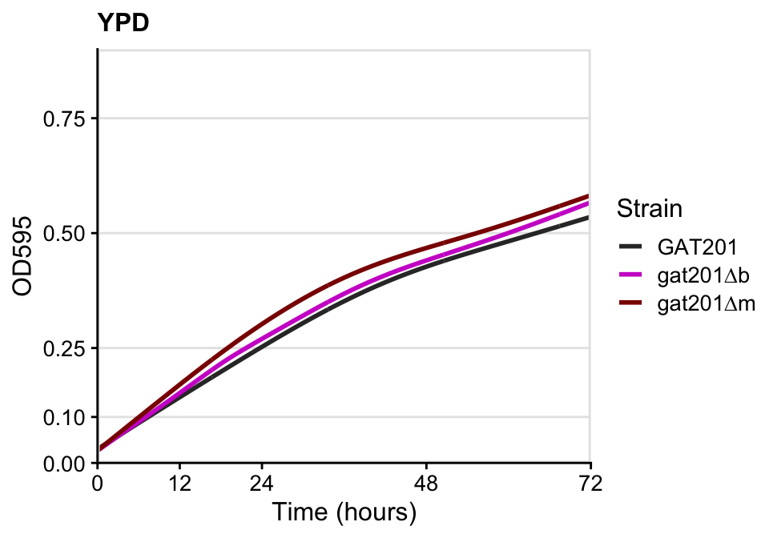

```r
YPD_spline_plot <-
  ggplot_growthcurve_spline(data_od = normalised_od_YPD %>%
                              filter(!is.na(Strain)),
                            value_od = "OD_corrected_time",
                            limits_time = c(0,72),
                            limits_od = c(0, 0.9),
                            breaks_od = c(0, 0.1, 0.25, 0.5, 0.75)) +
  scale_color_strain(strain_df)  +
  labs(title = "YPD")

YPD_spline_plot
```

# Multipanel Figure combining RPMI and YPD results

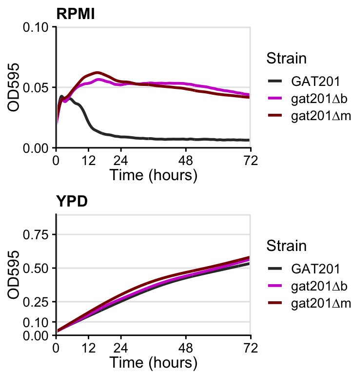

```r
multi_plot <-
  plot_grid(
    RPMI_spline_plot,
    YPD_spline_plot,
    ncol = 1)

multi_plot
```

```r
here::here("results",
           "fig_growthcurves_GAT201_RPMI_YPD.png") %>%
  ggsave(plot = multi_plot,
         width = 3.75, height = 4)
```

```r
here::here("results",
           "fig_growthcurves_GAT201_RPMI_YPD.svg") %>%
  ggsave(plot = multi_plot,
         width = 3.75, height = 4)
```